# OLA-Attrition

## About OLA 🚗

Ola is India’s largest mobility platform and one of the world’s largest ride-hailing companies, serving 250+ cities across India, Australia, New Zealand, and the UK. The Ola app offers mobility solutions by connecting customers to drivers and a wide range of vehicles across bikes, auto-rickshaws, metered taxis, and cabs, enabling convenience and transparency for hundreds of millions of consumers and over 1.5 million driver-partners.

### Business Problem 💡

Recruiting and retaining drivers is seen by industry watchers as a tough battle for Ola. Churn among drivers is high and it’s very easy for drivers to stop working for the service on the fly or jump to Uber depending on the rates.

As the companies get bigger, the high churn could become a bigger problem. To find new drivers, Ola is casting a wide net, including people who don’t have cars for jobs. But this acquisition is really costly. Losing drivers frequently impacts the morale of the organization and acquiring new drivers is more expensive than retaining existing ones.

We are provided with the monthly information for a segment of drivers for 2019 and 2020 and tasked to predict whether a driver will be leaving the company or not based on their attributes like:

- Demographics (city, age, gender etc.)
- Tenure information (joining date, Last Date)
- Historical data regarding the performance of the driver (Quarterly rating, Monthly business acquired, grade, Income)

### Dataset 📊

| **Column Name** | **Description** |
| --- | --- |
| **MMMM-YY** | Reporting Date (Monthly) |
| **Driver_ID** | Unique id for drivers |
| **Age** | Age of the driver |
| **Gender** | Gender of the driver – Male : 0, Female: 1 |
| **City** | City Code of the driver |
| **Education_Level** | Education level – 0 for 10+, 1 for 12+, 2 for graduate |
| **Income** | Monthly average Income of the driver |
| **Date Of Joining** | Joining date for the driver |
| **LastWorkingDate** | Last date of working for the driver |
| **Joining Designation** | Designation of the driver at the time of joining |
| **Grade** | Grade of the driver at the time of reporting |
| **Total Business Value** | The total business value acquired by the driver in a month (negative business indicates cancellation/refund or car EMI adjustments) |
| **Quarterly Rating** | Quarterly rating of the driver: 1, 2, 3, 4, 5 (higher is better) |

#### Importing Required Libraries 🤝

```python
import pandas as pd
import numpy as np

from matplotlib import pyplot as plt
import seaborn as sns
from xgboost import XGBClassifier
from lightgbm import LGBMClassifier
from catboost import CatBoostClassifier

from sklearn.model_selection import train_test_split, GridSearchCV, RandomizedSearchCV
from sklearn.metrics import accuracy_score, confusion_matrix, classification_report, roc_curve, roc_auc_score
from sklearn.metrics import precision_score, recall_score, f1_score
from sklearn.ensemble import GradientBoostingClassifier, RandomForestClassifier
from sklearn.preprocessing import LabelEncoder
from sklearn.preprocessing import StandardScaler
from sklearn.impute import KNNImputer

from imblearn.over_sampling import SMOTE
from collections import Counter

import warnings
warnings.filterwarnings('ignore')
```

```python
palette = ['#858585', '#D6DF22', '#EFEFEF', '#000000']
```

#### Read Dataset 🔍

```python
df = pd.read_csv(r'../data/ola_driver_scaler.csv', index_col=0)
df.head()
```

|  | MMM-YY | Driver_ID | Age | Gender | City | Education_Level | Income | Dateofjoining | LastWorkingDate | Joining Designation | Grade | Total Business Value | Quarterly Rating |
| --- | --- | --- | --- | --- | --- | --- | --- | --- | --- | --- | --- | --- | --- |
| 0 | 01/01/19 | 1 | 28.0 | 0.0 | C23 | 2 | 57387 | 24/12/18 | NaN | 1 | 1 | 2381060 | 2 |
| 1 | 02/01/19 | 1 | 28.0 | 0.0 | C23 | 2 | 57387 | 24/12/18 | NaN | 1 | 1 | -665480 | 2 |
| 2 | 03/01/19 | 1 | 28.0 | 0.0 | C23 | 2 | 57387 | 24/12/18 | 03/11/19 | 1 | 1 | 0 | 2 |
| 3 | 11/01/20 | 2 | 31.0 | 0.0 | C7 | 2 | 67016 | 11/06/20 | NaN | 2 | 2 | 0 | 1 |
| 4 | 12/01/20 | 2 | 31.0 | 0.0 | C7 | 2 | 67016 | 11/06/20 | NaN | 2 | 2 | 0 | 1 |

```python
print("Shape of the data: ", df.shape)
print("The Given Dataset has {} rows and {} columns".format(df.shape[0], df.shape[1]))
print("Columns: ", df.columns.to_list())
```

```
Shape of the data:  (19104, 13)
The Given Dataset has 19104 rows and 13 columns
Columns:  ['MMM-YY', 'Driver_ID', 'Age', 'Gender', 'City', 'Education_Level', 'Income', 'Dateofjoining', 'LastWorkingDate', 'Joining Designation', 'Grade', 'Total Business Value', 'Quarterly Rating']
```

### Shape 🕵🏽‍♂️

- The dataset comprises 19104 rows and 13 columns, representing a volume of data.
- Each row corresponds to monthly information for a segment of drivers.

### Data Structure 📰

```python
df.info()
```

```
<class 'pandas.core.frame.DataFrame'>
Index: 19104 entries, 0 to 19103
Data columns (total 13 columns):
 #   Column                Non-Null Count  Dtype
---  ------                --------------  -----
 0   MMM-YY                19104 non-null  object
 1   Driver_ID             19104 non-null  int64
 2   Age                   19043 non-null  float64
 3   Gender                19052 non-null  float64
 4   City                  19104 non-null  object
 5   Education_Level       19104 non-null  int64
 6   Income                19104 non-null  int64
 7   Dateofjoining         19104 non-null  object
 8   LastWorkingDate       1616 non-null   object
 9   Joining Designation   19104 non-null  int64
 10  Grade                 19104 non-null  int64
 11  Total Business Value  19104 non-null  int64
 12  Quarterly Rating      19104 non-null  int64
dtypes: float64(2), int64(7), object(4)
memory usage: 2.0+ MB
```

```python
df.isnull().sum()
```

```
MMM-YY                      0
Driver_ID                   0
Age                        61
Gender                     52
City                        0
Education_Level             0
Income                      0
Dateofjoining               0
LastWorkingDate         17488
Joining Designation         0
Grade                       0
Total Business Value        0
Quarterly Rating            0
dtype: int64
```

### 🕵🏽‍♂️ Dataset Information:

- **Data Consistency**: Age and Gender columns has values in the dataset. LastWorkingDate column has 17488 rows indicating there are still working for the organisation.
- **Data Types**: Columns are classified into integer, float and object types. DateTime columns are stored as Objects types.

```python
# # Missing Value Imputation - KNN Imputer
# imputer = KNNImputer(n_neighbors=3)
# df[['Age', 'Gender']] = imputer.fit_transform(df[['Age', 'Gender']])
# df.isnull().sum()
```

```python
df['Age'] = df.groupby(['Driver_ID'])['Age'].transform(lambda x: x.fillna(x.mean()))
df['Gender'] = df.groupby(['Driver_ID'])['Gender'].transform(lambda x: x.fillna(x.mean()))
```

```python
df['MMM-YY'] = pd.to_datetime(df['MMM-YY'])
df['Dateofjoining'] = pd.to_datetime(df['Dateofjoining'])
df['LastWorkingDate'] = pd.to_datetime(df['LastWorkingDate'])

df['Age'] = df['Age'].astype('int64')
df['Gender'] = df['Gender'].astype('int64').astype('category')
df['Education_Level'] = df['Education_Level'].astype('category')
df['Joining Designation'] = df['Joining Designation'].astype('category')
df['City'] = df['City'].astype('category')

df['is_churn'] = df['LastWorkingDate'].apply(lambda x: 1 if pd.isnull(x) else 0)
# df['is_churn'].value_counts()
df['is_churn'] = df['is_churn'].astype('int64')


df.dtypes
```

```
MMM-YY                  datetime64[ns]
Driver_ID                        int64
Age                              int64
Gender                        category
City                          category
Education_Level               category
Income                           int64
Dateofjoining           datetime64[ns]
LastWorkingDate         datetime64[ns]
Joining Designation           category
Grade                            int64
Total Business Value             int64
Quarterly Rating                 int64
is_churn                         int64
dtype: object
```

### 🕵🏽‍♂️ Missing Column Imputations:

```python
df.describe().T
```

|  | count | mean | min | 25% | 50% | 75% | max | std |
| --- | --- | --- | --- | --- | --- | --- | --- | --- |
| MMM-YY | 19104 | 2019-12-11 02:09:29.849246464 | 2019-01-01 00:00:00 | 2019-06-01 00:00:00 | 2019-12-01 00:00:00 | 2020-07-01 00:00:00 | 2020-12-01 00:00:00 | NaN |
| Driver_ID | 19104.0 | 1415.591133 | 1.0 | 710.0 | 1417.0 | 2137.0 | 2788.0 | 810.705321 |
| Age | 19104.0 | 34.64955 | 21.0 | 30.0 | 34.0 | 39.0 | 58.0 | 6.265274 |
| Income | 19104.0 | 65652.025126 | 10747.0 | 42383.0 | 60087.0 | 83969.0 | 188418.0 | 30914.515344 |
| Dateofjoining | 19104 | 2018-04-28 20:52:54.874371840 | 2013-04-01 00:00:00 | 2016-11-29 12:00:00 | 2018-09-12 00:00:00 | 2019-11-05 00:00:00 | 2020-12-28 00:00:00 | NaN |
| LastWorkingDate | 1616 | 2019-12-21 20:59:06.534653696 | 2018-12-31 00:00:00 | 2019-06-06 00:00:00 | 2019-12-20 12:00:00 | 2020-07-03 00:00:00 | 2020-12-28 00:00:00 | NaN |
| Grade | 19104.0 | 2.25267 | 1.0 | 1.0 | 2.0 | 3.0 | 5.0 | 1.026512 |
| Total Business Value | 19104.0 | 571662.074958 | -6000000.0 | 0.0 | 250000.0 | 699700.0 | 33747720.0 | 1128312.218461 |
| Quarterly Rating | 19104.0 | 2.008899 | 1.0 | 1.0 | 2.0 | 3.0 | 4.0 | 1.009832 |
| is_churn | 19104.0 | 0.91541 | 0.0 | 1.0 | 1.0 | 1.0 | 1.0 | 0.278277 |

```python
df.describe(include='category').T
```

|  | count | unique | top | freq |
| --- | --- | --- | --- | --- |
| Gender | 19104 | 2 | 0 | 11103 |
| City | 19104 | 29 | C20 | 1008 |
| Education_Level | 19104 | 3 | 1 | 6864 |
| Joining Designation | 19104 | 5 | 1 | 9831 |

### Preprocessing ⚙️

```python
df['LastWorkingDate'].fillna(pd.to_datetime('2020-12-31'), inplace=True)
df['tenture'] = (df['LastWorkingDate'] - df['Dateofjoining']).dt.days // 30
df['tenture'] = df['tenture'].astype('int64')

df.drop(['LastWorkingDate'], axis=1, inplace=True)
```

```python
# Create a column which tells whether the monthly income has increased for that driver - for those whose monthly income has increased we assign the value 1

df['monthly_income_increase'] = df.groupby('Driver_ID')['Income'].diff().apply(lambda x: 1 if x > 0 else 0)
df.head()
```

|  | MMM-YY | Driver_ID | Age | Gender | City | Education_Level | Income | Dateofjoining | Joining Designation | Grade | Total Business Value | Quarterly Rating | is_churn | tenture | monthly_income_increase |
| --- | --- | --- | --- | --- | --- | --- | --- | --- | --- | --- | --- | --- | --- | --- | --- |
| 0 | 2019-01-01 | 1 | 28 | 0 | C23 | 2 | 57387 | 2018-12-24 | 1 | 1 | 2381060 | 2 | 1 | 24 | 0 |
| 1 | 2019-02-01 | 1 | 28 | 0 | C23 | 2 | 57387 | 2018-12-24 | 1 | 1 | -665480 | 2 | 1 | 24 | 0 |
| 2 | 2019-03-01 | 1 | 28 | 0 | C23 | 2 | 57387 | 2018-12-24 | 1 | 1 | 0 | 2 | 0 | 2 | 0 |
| 3 | 2020-11-01 | 2 | 31 | 0 | C7 | 2 | 67016 | 2020-11-06 | 2 | 2 | 0 | 1 | 1 | 1 | 0 |
| 4 | 2020-12-01 | 2 | 31 | 0 | C7 | 2 | 67016 | 2020-11-06 | 2 | 2 | 0 | 1 | 1 | 1 | 0 |

```python
# Create a column which tells whether the quarterly rating has increased for that driver - for those whose quarterly rating has increased we assign the value 1
df['Quarter'] = df['MMM-YY'].dt.year.astype(str) + "-" + df['MMM-YY'].dt.quarter.astype(str)
df['quarterly_rating_increase'] = df.groupby(['Driver_ID', 'Quarter'])['Quarterly Rating'].diff().apply(lambda x: 1 if x > 0 else 0)

# # Update the quarterly_rating_increase field for all rows in that Quarter
# df['quarterly_rating_increase'] = df.groupby(['Driver_ID', 'Quarter'])['quarterly_rating_increase'].transform('max')

df.head()
```

|  | MMM-YY | Driver_ID | Age | Gender | City | Education_Level | Income | Dateofjoining | Joining Designation | Grade | Total Business Value | Quarterly Rating | is_churn | tenture | monthly_income_increase | Quarter | quarterly_rating_increase |
| --- | --- | --- | --- | --- | --- | --- | --- | --- | --- | --- | --- | --- | --- | --- | --- | --- | --- |
| 0 | 2019-01-01 | 1 | 28 | 0 | C23 | 2 | 57387 | 2018-12-24 | 1 | 1 | 2381060 | 2 | 1 | 24 | 0 | 2019-1 | 0 |
| 1 | 2019-02-01 | 1 | 28 | 0 | C23 | 2 | 57387 | 2018-12-24 | 1 | 1 | -665480 | 2 | 1 | 24 | 0 | 2019-1 | 0 |
| 2 | 2019-03-01 | 1 | 28 | 0 | C23 | 2 | 57387 | 2018-12-24 | 1 | 1 | 0 | 2 | 0 | 2 | 0 | 2019-1 | 0 |
| 3 | 2020-11-01 | 2 | 31 | 0 | C7 | 2 | 67016 | 2020-11-06 | 2 | 2 | 0 | 1 | 1 | 1 | 0 | 2020-4 | 0 |
| 4 | 2020-12-01 | 2 | 31 | 0 | C7 | 2 | 67016 | 2020-11-06 | 2 | 2 | 0 | 1 | 1 | 1 | 0 | 2020-4 | 0 |

```python
# driver_with_rating_increase = df[df['quarterly_rating_increase']==1]['Driver_ID'].values[0]
# df[df['Driver_ID']==driver_with_rating_increase]
```

[output not shown]

```python
df.sample(5)
```

|  | MMM-YY | Driver_ID | Age | Gender | City | Education_Level | Income | Dateofjoining | Joining Designation | Grade | Total Business Value | Quarterly Rating | is_churn | tenture | monthly_income_increase | Quarter | quarterly_rating_increase |
| --- | --- | --- | --- | --- | --- | --- | --- | --- | --- | --- | --- | --- | --- | --- | --- | --- | --- |
| 14283 | 2019-06-01 | 2134 | 38 | 0 | C29 | 0 | 116006 | 2013-10-30 | 2 | 5 | 858440 | 3 | 1 | 87 | 0 | 2019-2 | 0 |
| 9869 | 2020-10-01 | 1468 | 31 | 0 | C20 | 1 | 66779 | 2020-09-01 | 3 | 3 | 0 | 1 | 1 | 4 | 0 | 2020-4 | 0 |
| 18931 | 2020-07-01 | 2761 | 28 | 0 | C20 | 2 | 131805 | 2020-07-17 | 3 | 3 | 0 | 1 | 1 | 5 | 0 | 2020-3 | 0 |
| 18707 | 2020-11-01 | 2729 | 35 | 0 | C10 | 0 | 107274 | 2019-08-04 | 4 | 4 | 718850 | 1 | 1 | 17 | 0 | 2020-4 | 0 |
| 10930 | 2019-01-01 | 1635 | 29 | 0 | C20 | 0 | 13417 | 2018-12-31 | 1 | 1 | 110280 | 1 | 1 | 24 | 0 | 2019-1 | 0 |

```python
# # df[df['Age'].isna()]
# df[df['Driver_ID']==20]
```

[output not shown]

```python
df.isna().sum()
```

```
MMM-YY                       0
Driver_ID                    0
Age                          0
Gender                       0
City                         0
Education_Level              0
Income                       0
Dateofjoining                0
Joining Designation          0
Grade                        0
Total Business Value         0
Quarterly Rating             0
is_churn                     0
tenture                      0
monthly_income_increase      0
Quarter                      0
quarterly_rating_increase    0
dtype: int64
```

```python
df_processed = df.groupby('Driver_ID').agg(
    {
        'Age': 'last',
        'Gender': 'last',
        'City': 'last',
        'Education_Level': 'last',
        'Income': 'mean',
        'Dateofjoining': 'last',
        'Joining Designation': 'last',
        'Grade': 'last',
        'Total Business Value': 'sum',
        'is_churn': 'last',
        'monthly_income_increase': 'sum',
        'quarterly_rating_increase': 'sum',
        'tenture': 'last'
        }
    ).reset_index()
```

```python
df_processed.describe().T
```

|  | count | mean | min | 25% | 50% | 75% | max | std |
| --- | --- | --- | --- | --- | --- | --- | --- | --- |
| Driver_ID | 2381.0 | 1397.559009 | 1.0 | 695.0 | 1400.0 | 2100.0 | 2788.0 | 806.161628 |
| Age | 2381.0 | 33.661907 | 21.0 | 29.0 | 33.0 | 37.0 | 58.0 | 5.984674 |
| Income | 2381.0 | 59232.460484 | 10747.0 | 39104.0 | 55285.0 | 75835.0 | 188418.0 | 28298.214012 |
| Dateofjoining | 2381 | 2019-02-08 07:14:50.550189056 | 2013-04-01 00:00:00 | 2018-06-29 00:00:00 | 2019-07-21 00:00:00 | 2020-05-02 00:00:00 | 2020-12-28 00:00:00 | NaN |
| Grade | 2381.0 | 2.096598 | 1.0 | 1.0 | 2.0 | 3.0 | 5.0 | 0.941522 |
| Total Business Value | 2381.0 | 4586741.822764 | -1385530.0 | 0.0 | 817680.0 | 4173650.0 | 95331060.0 | 9127115.313446 |
| is_churn | 2381.0 | 0.321294 | 0.0 | 0.0 | 0.0 | 1.0 | 1.0 | 0.467071 |
| monthly_income_increase | 2381.0 | 0.01848 | 0.0 | 0.0 | 0.0 | 0.0 | 1.0 | 0.134706 |
| quarterly_rating_increase | 2381.0 | 0.00336 | 0.0 | 0.0 | 0.0 | 0.0 | 1.0 | 0.05788 |
| tenture | 2381.0 | 14.104998 | 0.0 | 3.0 | 6.0 | 16.0 | 94.0 | 18.92184 |

```python
print("Shape of the processed data: ", df_processed.shape)
print("The Processed Dataset has {} rows and {} columns".format(df_processed.shape[0], df_processed.shape[1]))
```

```
Shape of the processed data:  (2381, 14)
The Processed Dataset has 2381 rows and 14 columns
```

### Exploratory Data Analysis (EDA) 💹

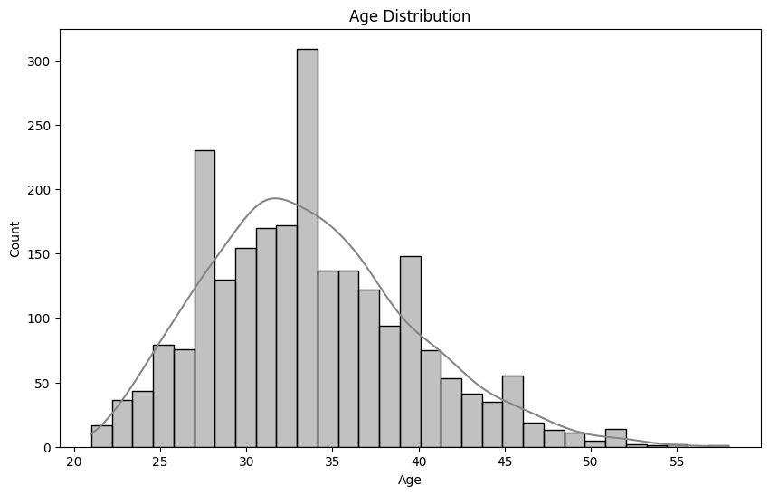

```python
# Age distribution
plt.figure(figsize=(10, 6))
sns.histplot(df_processed['Age'], kde=True, color=palette[0])
plt.title('Age Distribution')
plt.show()
```

### Insight 🕵🏽‍♂️

- The ages of individuals in the dataset range from approximately 20 to 55 years.
- The distribution appears to be right-skewed, with the majority of individuals clustered around the ages of 30 to 40 years.
- The peak of the distribution is around the age of 35, indicating that this is the most common age group in the dataset.
- The number of individuals decreases steadily for ages above 40, with very few individuals above the age of 50.

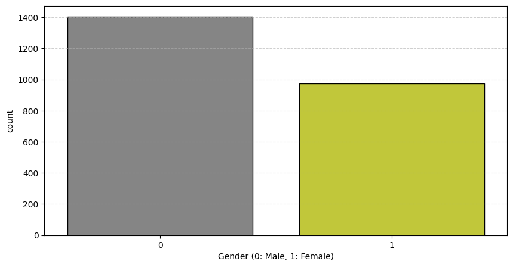

```
Gender
0    0.589668
1    0.410332
Name: proportion, dtype: float64
```

```python
# Gender distribution
plt.figure(figsize=(10, 5))
sns.countplot(df_processed, x='Gender', palette=palette, edgecolor='black')
plt.xlabel('Gender (0: Male, 1: Female)')
plt.grid(axis='y', linestyle='--', alpha=0.6)
plt.show()

print(df_processed['Gender'].value_counts(normalize=True))
```

### Insight 🕵🏽‍♂️

- The distribution of gender, around 59% of drivers are Male, 41% are Females.

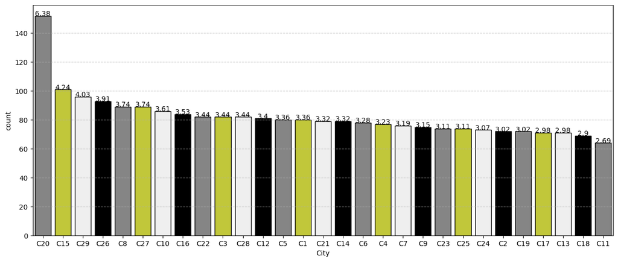

```python
# City distribution
plt.figure(figsize=(15, 6))
sns.countplot(df_processed, x='City', palette=palette, order=df_processed['City'].value_counts().index, edgecolor='black')
plt.xlabel('City')
plt.grid(axis='y', linestyle='--', alpha=0.6)

for i in range(len(df_processed['City'].value_counts())):
    plt.text(i, df_processed['City'].value_counts()[i], round(df_processed['City'].value_counts(normalize=True)[i]*100, 2), ha = 'center')

plt.show()
```

### Insight 🕵🏽‍♂️

- Around 6.4% of the driver from city code C20.
- Rest of the city has driver representating 2.5% to 4.2%

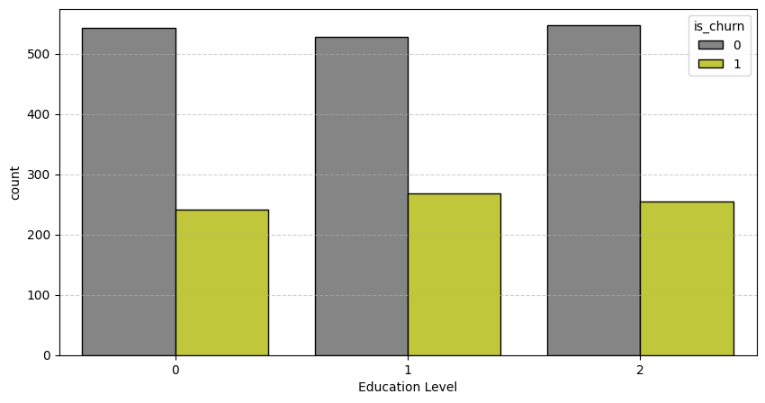

```
Education_Level
2    0.336833
1    0.333893
0    0.329273
Name: proportion, dtype: float64
```

```python
# Education Level distribution
plt.figure(figsize=(10, 5))
sns.countplot(df_processed, x='Education_Level', hue='is_churn' ,palette=palette, edgecolor='black')
plt.xlabel('Education Level')
plt.grid(axis='y', linestyle='--', alpha=0.6)
plt.show()

df_processed['Education_Level'].value_counts(normalize=True)
```

### Insight 🕵🏽‍♂️

- Almost 33% percentages of drivers has in each education level

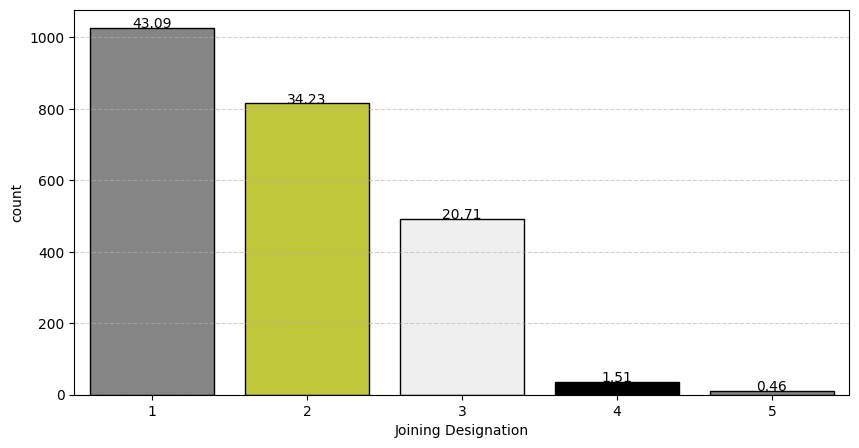

```python
# Joining Designation distribution
plt.figure(figsize=(10, 5))
sns.countplot(df_processed, x='Joining Designation', palette=palette, order=df_processed['Joining Designation'].value_counts().index, edgecolor='black')
plt.xlabel('Joining Designation')
plt.grid(axis='y', linestyle='--', alpha=0.6)

for i, val in enumerate(df_processed['Joining Designation'].value_counts().index):
    count = df_processed['Joining Designation'].value_counts()[val]
    percentage = round(df_processed['Joining Designation'].value_counts(normalize=True)[val] * 100, 2)
    plt.text(i, count, percentage, ha='center')

plt.show()
```

### Insight 🕵🏽‍♂️

- Joining Designation distribution is around 43% with Designation 1 and ~1.5% with Designation 4 and 0.5% with Designation 5.
- Joining Designation distribution indicate that only ~2% joins with higher designation.

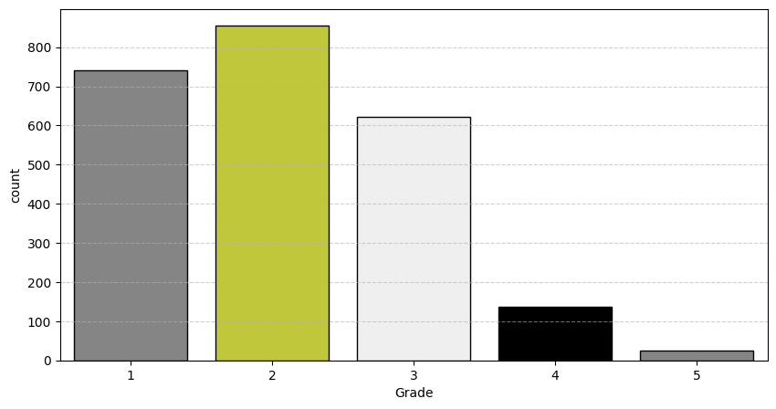

```python
# Grade distribution
plt.figure(figsize=(10, 5))
sns.countplot(df_processed, x='Grade', palette=palette, edgecolor='black')
plt.xlabel('Grade')
plt.grid(axis='y', linestyle='--', alpha=0.6)
plt.show()
```

### Insight 🕵🏽‍♂️

- More number of driver falls with Grade 2.
- Driver in grade 4 and 5 are relavatively lower than other grades

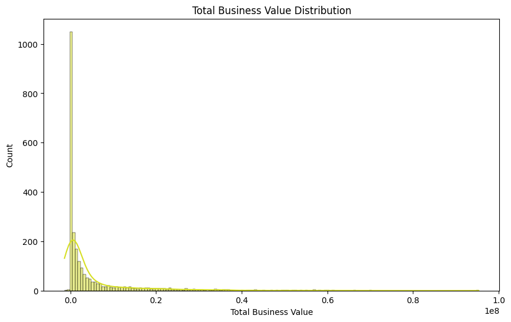

```python
# Total Business Value distribution
plt.figure(figsize=(10, 6))
sns.histplot(df_processed['Total Business Value'], kde=True, color=palette[1])
plt.title('Total Business Value Distribution')
plt.show()
```

### Insight 🕵🏽‍♂️

- The distribution is highly right-skewed. This indicates that a large number of users generate relatively low business value, while a small number of users generate very high business value.
- The majority of users generate a total business value close to zero.

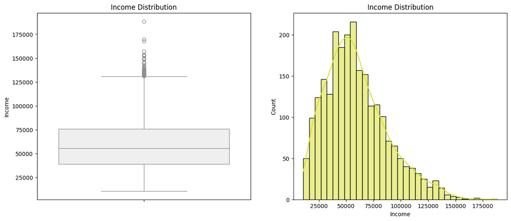

```python
# Income distribution using boxplot and histogram
plt.figure(figsize=(15, 6))
plt.subplot(1, 2, 1)
sns.boxplot(df_processed['Income'], color=palette[2])
plt.title('Income Distribution')

plt.subplot(1, 2, 2)
sns.histplot(df_processed['Income'], kde=True, color=palette[1])
plt.title('Income Distribution')
plt.show()
```

### Insight 🕵🏽‍♂️

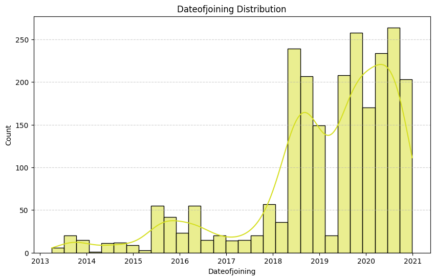

```python
# Dateofjoining distribution
plt.figure(figsize=(10, 6))
sns.histplot(df_processed['Dateofjoining'], kde=True, color=palette[1])
plt.title('Dateofjoining Distribution')
plt.grid(axis='y', linestyle='--', alpha=0.6)
plt.show()
```

### Insight 🕵🏽‍♂️

- There is significant number of driver joined after mid 2018.
- 2020 Q3 has highest number of driver onboarded.

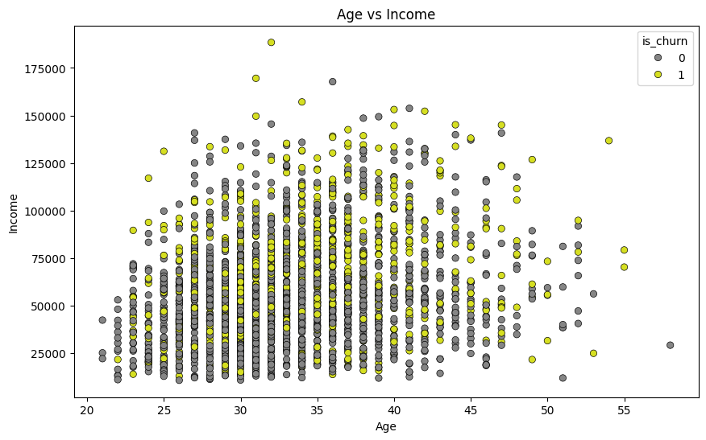

```python
# Age vs Income
plt.figure(figsize=(10, 6))
sns.scatterplot(data=df_processed, x='Age', y='Income', hue='is_churn', palette=palette, edgecolor='black')
plt.title('Age vs Income')
plt.show()
```

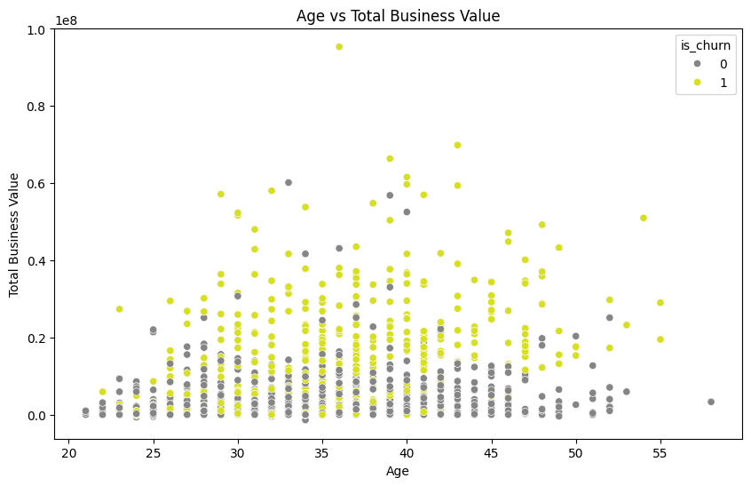

```python
# Age vs Total Business Value
plt.figure(figsize=(10, 6))
sns.scatterplot(data=df_processed, x='Age', y='Total Business Value', hue='is_churn', palette=palette)
plt.title('Age vs Total Business Value')
plt.show()
```

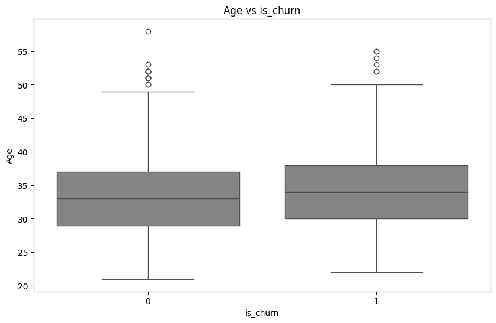

```python
# Age vs is_churn
plt.figure(figsize=(10, 6))
sns.boxplot(data=df_processed, x='is_churn', y='Age', color=palette[0])
plt.title('Age vs is_churn')
plt.show()
```

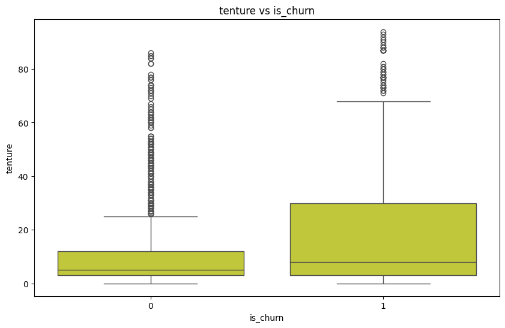

```python
# tenture vs is_churn
plt.figure(figsize=(10, 6))
sns.boxplot(data=df_processed, x='is_churn', y='tenture', color=palette[1])
plt.title('tenture vs is_churn')
plt.show()
```

### Insight 🕵🏽‍♂️

- The median tenure for customers who have not churned (is_churn = 0) is significantly lower compared to those who have churned (is_churn = 1).
- This suggests that customers who stay with the service tend to have shorter tenures on average compared to those who eventually churn.
- There are more outliers with higher tenures in the non-churn group. This indicates that while most non-churned customers have shorter tenures, there are a few who have stayed for a significantly longer period.

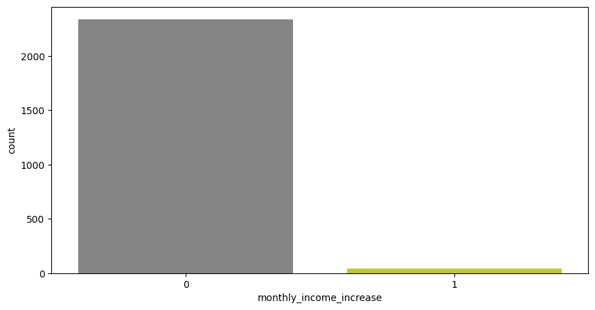

```python
# monthly_income_increase distribution
plt.figure(figsize=(10, 5))
sns.countplot(df_processed, x='monthly_income_increase', palette=palette)
plt.xlabel('monthly_income_increase')
plt.show()
```

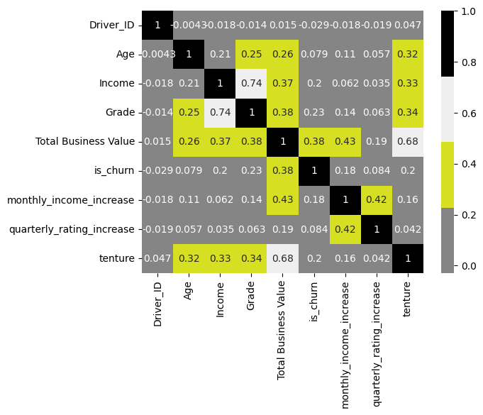

```python
numeric_df = df_processed.select_dtypes(include=[np.number])
sns.heatmap(numeric_df.corr(), annot=True, cmap=palette)
```

- Income and Grade has significant correlations between them.

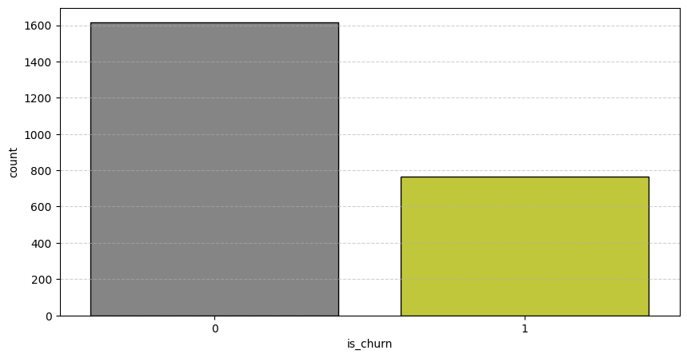

```
is_churn
0    1616
1     765
Name: count, dtype: int64
```

```python
# is_churn distribution
plt.figure(figsize=(10, 5))
sns.countplot(df_processed, x='is_churn', palette=palette, edgecolor='black')
plt.xlabel('is_churn')
plt.grid(axis='y', linestyle='--', alpha=0.6)
plt.show()

df_processed['is_churn'].value_counts()
```

## Data preparation for Modelling 🤼

```python
# One hot encoding of the categorical variable
df_processed = pd.get_dummies(df_processed, columns=['City', 'Gender'], dtype=int, drop_first=True)
df_processed.head()

# df_processed['Gender'] = df_processed['Gender'].astype('int64')
```

|  | Driver_ID | Age | Education_Level | Income | Dateofjoining | Joining Designation | Grade | Total Business Value | is_churn | monthly_income_increase | ... | City_C28 | City_C29 | City_C3 | City_C4 | City_C5 | City_C6 | City_C7 | City_C8 | City_C9 | Gender_1 |
| --- | --- | --- | --- | --- | --- | --- | --- | --- | --- | --- | --- | --- | --- | --- | --- | --- | --- | --- | --- | --- | --- |
| 0 | 1 | 28 | 2 | 57387.0 | 2018-12-24 | 1 | 1 | 1715580 | 0 | 0 | ... | 0 | 0 | 0 | 0 | 0 | 0 | 0 | 0 | 0 | 0 |
| 1 | 2 | 31 | 2 | 67016.0 | 2020-11-06 | 2 | 2 | 0 | 1 | 0 | ... | 0 | 0 | 0 | 0 | 0 | 0 | 1 | 0 | 0 | 0 |
| 2 | 4 | 43 | 2 | 65603.0 | 2019-12-07 | 2 | 2 | 350000 | 0 | 0 | ... | 0 | 0 | 0 | 0 | 0 | 0 | 0 | 0 | 0 | 0 |
| 3 | 5 | 29 | 0 | 46368.0 | 2019-01-09 | 1 | 1 | 120360 | 0 | 0 | ... | 0 | 0 | 0 | 0 | 0 | 0 | 0 | 0 | 1 | 0 |
| 4 | 6 | 31 | 1 | 78728.0 | 2020-07-31 | 3 | 3 | 1265000 | 1 | 0 | ... | 0 | 0 | 0 | 0 | 0 | 0 | 0 | 0 | 0 | 1 |

5 rows × 41 columns

```python
# Label Encoding for 'Education_Level', 'Joining Designation', 'Grade'
le = LabelEncoder()
df_processed['Education_Level'] = le.fit_transform(df_processed['Education_Level'])
df_processed['Joining Designation'] = le.fit_transform(df_processed['Joining Designation'])
df_processed['Grade'] = le.fit_transform(df_processed['Grade'])
```

```python
# Class imbalance Treatment
X = df_processed.drop(['Driver_ID', 'is_churn', 'Dateofjoining'], axis=1)
y = df_processed['is_churn']

print('Original dataset shape %s' % Counter(y))

sm = SMOTE(random_state=42)
X_res, y_res = sm.fit_resample(X, y)
print('Resampled dataset shape %s' % Counter(y_res))

df_resampled = pd.concat([X_res, y_res], axis=1)
df_resampled.head()
```

```
Original dataset shape Counter({0: 1616, 1: 765})
Resampled dataset shape Counter({0: 1616, 1: 1616})
```

|  | Age | Education_Level | Income | Joining Designation | Grade | Total Business Value | monthly_income_increase | quarterly_rating_increase | tenture | City_C10 | ... | City_C29 | City_C3 | City_C4 | City_C5 | City_C6 | City_C7 | City_C8 | City_C9 | Gender_1 | is_churn |
| --- | --- | --- | --- | --- | --- | --- | --- | --- | --- | --- | --- | --- | --- | --- | --- | --- | --- | --- | --- | --- | --- |
| 0 | 28 | 2 | 57387.0 | 0 | 0 | 1715580 | 0 | 0 | 2 | 0 | ... | 0 | 0 | 0 | 0 | 0 | 0 | 0 | 0 | 0 | 0 |
| 1 | 31 | 2 | 67016.0 | 1 | 1 | 0 | 0 | 0 | 1 | 0 | ... | 0 | 0 | 0 | 0 | 0 | 1 | 0 | 0 | 0 | 1 |
| 2 | 43 | 2 | 65603.0 | 1 | 1 | 350000 | 0 | 0 | 4 | 0 | ... | 0 | 0 | 0 | 0 | 0 | 0 | 0 | 0 | 0 | 0 |
| 3 | 29 | 0 | 46368.0 | 0 | 0 | 120360 | 0 | 0 | 1 | 0 | ... | 0 | 0 | 0 | 0 | 0 | 0 | 0 | 1 | 0 | 0 |
| 4 | 31 | 1 | 78728.0 | 2 | 2 | 1265000 | 0 | 0 | 5 | 0 | ... | 0 | 0 | 0 | 0 | 0 | 0 | 0 | 0 | 1 | 1 |

5 rows × 39 columns

```python
# # Scaling the data - Not required for tree based models
# scaler = StandardScaler()
# X_scaled = scaler.fit_transform(X_res)
# X_scaled = pd.DataFrame(X_scaled, columns=X.columns)
# X_scaled.head()
```

```python
# Splitting the data into training and testing
X_train, X_test, y_train, y_test = train_test_split(X_res, y_res, test_size=0.2, random_state=21)

X_train.shape, X_test.shape, y_train.shape, y_test.shape
```

```
((2585, 38), (647, 38), (2585,), (647,))
```

### Bagging Algorithm

```
Parameters:  {'bootstrap': True, 'ccp_alpha': 0.0, 'class_weight': None, 'criterion': 'gini', 'max_depth': None, 'max_features': 'sqrt', 'max_leaf_nodes': None, 'max_samples': None, 'min_impurity_decrease': 0.0, 'min_samples_leaf': 1, 'min_samples_split': 2, 'min_weight_fraction_leaf': 0.0, 'monoton…
Training Score:  1.0
Test Score:  0.8068006182380216
Classification Report:
               precision    recall  f1-score   support

           0       0.78      0.83      0.81       314
           1       0.83      0.78      0.81       333

    accuracy                           0.81       647
   macro avg       0.81      0.81      0.81       647
weighted avg       0.81      0.81      0.81       647

Confusion Matrix:
 [[261  53]
 [ 72 261]]
```

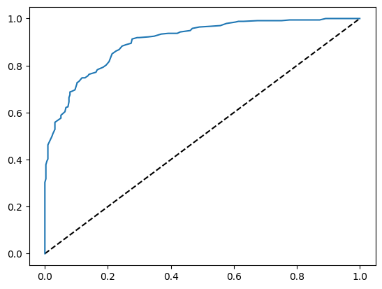

```python
# Model Building - Random Forest

rf = RandomForestClassifier(random_state=42)
rf.fit(X_train, y_train)
y_pred = rf.predict(X_test)

print('Parameters: ', rf.get_params())

print('Training Score: ', rf.score(X_train, y_train))
print('Test Score: ', accuracy_score(y_test, y_pred))
print('Classification Report: \n', classification_report(y_test, y_pred))
print('Confusion Matrix: \n', confusion_matrix(y_test, y_pred))

# ROC Curve
y_pred_prob = rf.predict_proba(X_test)[:, 1]
fpr, tpr, thresholds = roc_curve(y_test, y_pred_prob)
plt.plot([0, 1], [0, 1], 'k--')
plt.plot(fpr, tpr)
```

#### Insight:

- Train accuracy is 100% which indicate model fits very well with data.
- Test accuracy is 80% which is good but lesser than the Train accuracy, indicating potiential overfitting.
- Additional tuning of hyperparameters could improve the model's generalization ability.

[output not shown]

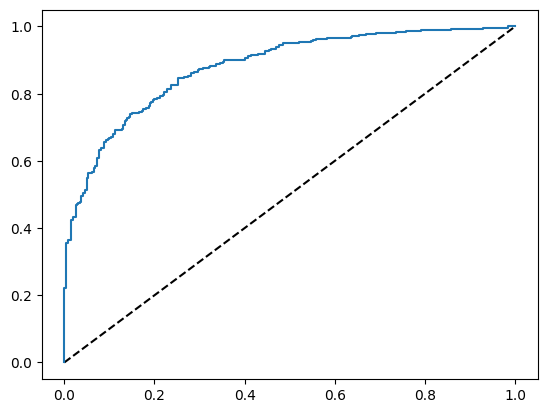

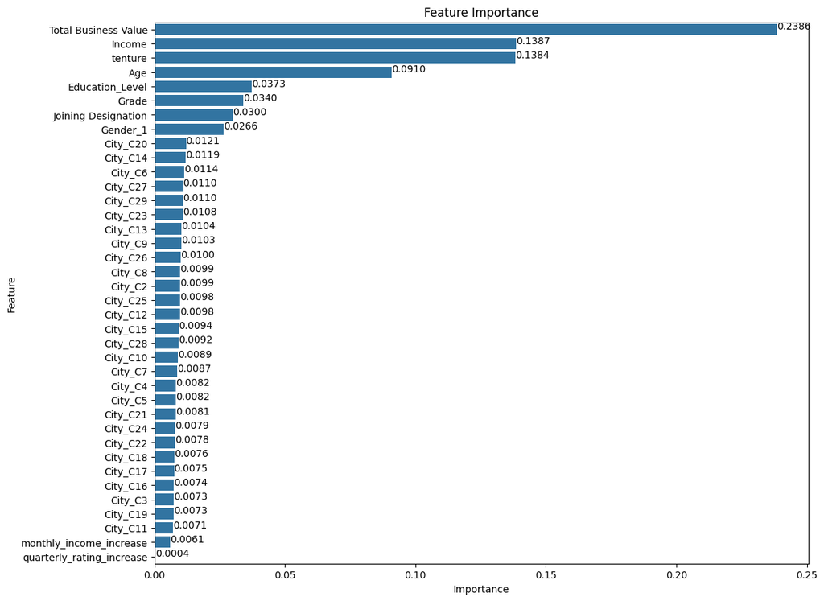

```python
# Hyperparameter Tuning - RandomizedSearchCV

# Define a more extensive parameter grid for Random Search
params = {
    'n_estimators': [int(x) for x in range(100, 1000, 100)],
    'max_depth': [None] + [int(x) for x in range(10, 110, 10)],
    'min_samples_split': [2, 5, 10],
    'min_samples_leaf': [1, 2, 4],
    'max_features': ['log2', 'sqrt'],
    'bootstrap': [True, False]
}

# Initialize the RandomForest classifier
rf = RandomForestClassifier(random_state=42)

cv = RandomizedSearchCV(estimator=rf, param_distributions=params, n_iter=100, cv=5, verbose=1, random_state=42, n_jobs=-1, scoring='accuracy')
cv.fit(X_train, y_train)

print("Best parameters found: ", cv.best_params_)
print("Best cross-validation score achieved: ", cv.best_score_)

# Model Building - With Best Hyperparameters
params = cv.best_params_

rf = RandomForestClassifier(**params, random_state=42)
rf.fit(X_train, y_train)
y_pred = rf.predict(X_test)

print('Parameters: ', rf.get_params())
print('Training Score: ', rf.score(X_train, y_train))
print('Test Score: ', accuracy_score(y_test, y_pred))

print('Classification Report: \n', classification_report(y_test, y_pred))
print('Confusion Matrix: \n', confusion_matrix(y_test, y_pred))

# ROC Curve
y_pred_prob = rf.predict_proba(X_test)[:, 1]
fpr, tpr, thresholds = roc_curve(y_test, y_pred_prob)
plt.plot([0, 1], [0, 1], 'k--')
plt.plot(fpr, tpr)

# Feature Importance
feature_importance = pd.DataFrame({'Feature': X.columns, 'Importance': rf.feature_importances_})
feature_importance = feature_importance.sort_values(by='Importance', ascending=False)

plt.figure(figsize=(12, 10))
sns.barplot(data=feature_importance, x='Importance', y='Feature')
plt.title('Feature Importance')

# Show the value at the end of each bar
for index, value in enumerate(feature_importance['Importance']):
    plt.text(value, index, f'{value:.4f}')

plt.show()
```

## Key Insights

### Class-wise Performance

#### Feature Important

- **Total Business Value**
- **tenture**
- **Income**
- **Age**

Are the top features for our model predictation.

### Boosting Algorithm

```python
# Splitting the data into training and testing
X_train, X_test, y_train, y_test = train_test_split(X_res, y_res, test_size=0.2, random_state=42)

X_train.shape, X_test.shape, y_train.shape, y_test.shape
```

```
((2585, 38), (647, 38), (2585,), (647,))
```

```python
models = {
    'Gradient Boosting': GradientBoostingClassifier(n_estimators=100, random_state=42),
    'XGBoost': XGBClassifier(n_estimators=100, random_state=42, use_label_encoder=False, eval_metric='logloss'),
    'LightGBM': LGBMClassifier(n_estimators=100, random_state=42),
    'CatBoost': CatBoostClassifier(n_estimators=100, random_state=42, verbose=0)
}
```

```python
# Evaluating different models
results = {}

for name, model in models.items():
    # Train the model
    model.fit(X_train, y_train)

    # Predict on the test set
    y_pred = model.predict(X_test)

    # Evaluate the model
    train_accuracy = model.score(X_train, y_train)
    accuracy = accuracy_score(y_test, y_pred)
    precision = precision_score(y_test, y_pred)
    recall = recall_score(y_test, y_pred)
    f1 = f1_score(y_test, y_pred)
    roc_auc = roc_auc_score(y_test, y_pred)

    # Store the results
    results[name] = {
        'Train Accuracy': train_accuracy,
        'Test Accuracy': accuracy,
        'Precision': precision,
        'Recall': recall,
        'F1 Score': f1,
        'ROC AUC': roc_auc
    }

results_df = pd.DataFrame(results).T
results_df
```

[output not shown]

|  | Train Accuracy | Test Accuracy | Precision | Recall | F1 Score | ROC AUC |
| --- | --- | --- | --- | --- | --- | --- |
| Gradient Boosting | 0.845648 | 0.778980 | 0.788644 | 0.766871 | 0.777605 | 0.779074 |
| XGBoost | 0.974468 | 0.800618 | 0.797583 | 0.809816 | 0.803653 | 0.800547 |
| LightGBM | 0.952805 | 0.799073 | 0.816129 | 0.776074 | 0.795597 | 0.799252 |
| CatBoost | 0.893617 | 0.786708 | 0.793750 | 0.779141 | 0.786378 | 0.786767 |

### Insight:

XGBoost demonstrates the highest training accuracy, which suggests it fits the training data very well. However, the significant difference between train and test accuracy indicates overfitting. Despite this, XGBoost achieves the highest test accuracy and F1 Score among the models, making it a strong candidate for predicting churn, provided overfitting is addressed.

#### XGBoost Classifier

```python
# Define the parameter grid based on RandomizedSearchCV results
param_grid = {
    'n_estimators': [100, 200, 300],
    'learning_rate': [0.01, 0.05, 0.1],
    'max_depth': [6, 7, 8],
    'min_child_weight': [1, 3, 5],
    'gamma': [0, 0.1, 0.2],
    'subsample': [0.8, 0.9, 1.0],
    'colsample_bytree': [0.8, 0.9, 1.0]
}

xgb_model = XGBClassifier(random_state=42, use_label_encoder=False, eval_metric='logloss')

# Set up the RandomizedSearchCV
cv = RandomizedSearchCV(estimator=xgb_model, param_distributions=param_grid, cv=5, n_jobs=-1, verbose=2, scoring='accuracy')

# Fit the model
cv.fit(X_train, y_train)

# Best parameters and score
print("Best parameters found: ", cv.best_params_)
print("Best cross-validation score achieved: ", cv.best_score_)
```

```
Fitting 5 folds for each of 10 candidates, totalling 50 fits
Best parameters found:  {'subsample': 0.9, 'n_estimators': 300, 'min_child_weight': 1, 'max_depth': 7, 'learning_rate': 0.05, 'gamma': 0.1, 'colsample_bytree': 1.0}
Best cross-validation score achieved:  0.8123791102514506
```

```
Training Score:  0.9620889748549323
Test Score:  0.8145285935085008
Classification Report:
               precision    recall  f1-score   support

           0       0.81      0.82      0.81       321
           1       0.82      0.81      0.82       326

    accuracy                           0.81       647
   macro avg       0.81      0.81      0.81       647
weighted avg       0.81      0.81      0.81       647

Confusion Matrix:
 [[262  59]
 [ 61 265]]
```

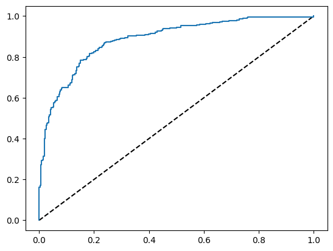

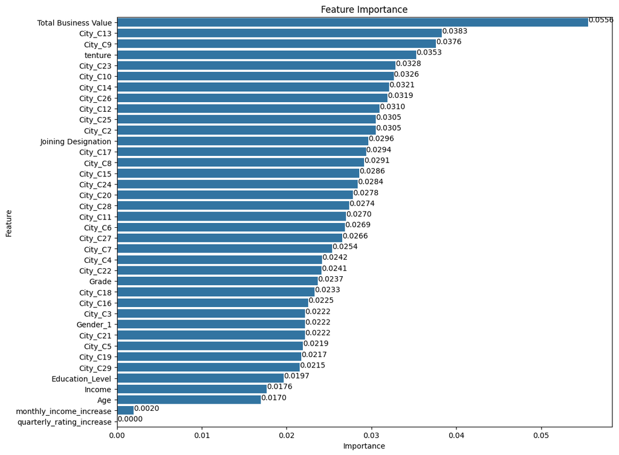

```python
# Train the model with the best parameters
params = cv.best_params_
xgb_model = XGBClassifier(**params, use_label_encoder=False, eval_metric='logloss', random_state=42)
xgb_model.fit(X_train, y_train)
y_pred = xgb_model.predict(X_test)

print("Training Score: ", xgb_model.score(X_train, y_train))
print("Test Score: ", xgb_model.score(X_test, y_test))
print("Classification Report: \n", classification_report(y_test, y_pred))
print("Confusion Matrix: \n", confusion_matrix(y_test, y_pred))

# ROC Curve
y_pred_prob = xgb_model.predict_proba(X_test)[:, 1]
fpr, tpr, thresholds = roc_curve(y_test, y_pred_prob)
plt.plot([0, 1], [0, 1], 'k--')
plt.plot(fpr, tpr)

# Feature Importance
feature_importance = pd.DataFrame({'Feature': X.columns, 'Importance': xgb_model.feature_importances_})
feature_importance = feature_importance.sort_values(by='Importance', ascending=False)

plt.figure(figsize=(12, 10))
sns.barplot(data=feature_importance, x='Importance', y='Feature')
plt.title('Feature Importance')

# Show the value at the end of each bar
for index, value in enumerate(feature_importance['Importance']):
    plt.text(value, index, f'{value:.4f}')

plt.show()
```

## Key Insights:

- The model achieved a training accuracy of 96.21%, indicating that it fits the training data very well. However, this high training score compared to the test score suggests potential overfitting.
- The test accuracy is 81.45%, which is a strong performance, indicating that the model generalizes well to unseen data, though not as perfectly as it does with the training data.
- Both classes (0 and 1) have similar precision and recall values (~0.81-0.82), indicating that the model is equally good at identifying both churners and non-churners. This balance is crucial for maintaining a low false positive and false negative rate.
- Both macro and weighted averages for precision, recall, and F1-score are 0.81, reinforcing the model's balanced performance across both classes.

### Actionable Insight and Recommendations

- **Retention Strategies:**

Focus retention efforts on newer drivers, as those with shorter tenures are more likely to stay. Implement additional engagement strategies for drivers with longer tenures to prevent churn.

- **Driver Segmentation:**

Segment drivers based on tenure and age to tailor specific interventions. For example, provide loyalty rewards or personalized offers to long-tenured drivers.

- **Training and Support:**

Provide robust training and support during the initial months to help retain new drivers. Ensuring they feel valued and supported could reduce early churn.

- **Incentive Programs:**